# HW6

Xuan Wen Loo

2024-03-01

## Problem 1

1. It is not a must for the statement to be true. As the number of predictors increases, $M_{k+1}$ may find a better predictors combination that gives a smaller RSS value, and hence does not include the predictor in $M_k$.
2. Yes. Everytime k increments by 1, it takes the existing model and adds one more predictor that will give the smallest RSS. So the future models will always contain a subset of predictors from the previous models.
3. When k=1, all three methods will give the same result since they involve selecting one predictor only. However, as k increases, the models produced by forward and backward selections will most likely have smaller training MSE as compared to the model produced by subset selection. This is because forward and backward selection algorithms are designed to iteratively add or remove predictors based on their contribution to reducing the training error. On the other hand, subset selection evaluates all possible combinations of predictors which can lead to overfitting and got a higher training error.
4. The model produced by forward selection is expected to have the smallest test MSE. This is because forward selection builds the model by iteratively adding predictors that improve the model’s performance, which often results in a better generalization to unseen data.

## Problem 2

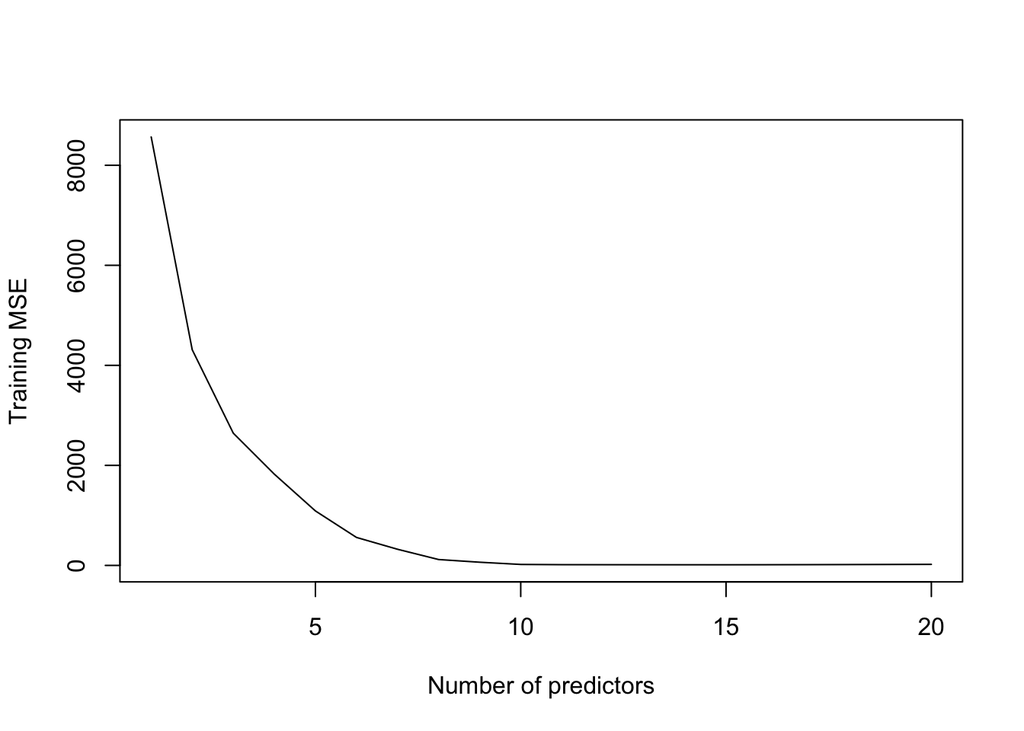

```r
p = 20
n = 1000
error = rnorm(n,0,1)
beta = c(2, rep(0,5),1.2,3,-2,1.5,7,rep(0,5),3,4,1,9,2)
Xmat = matrix(rnorm(n*20),n,20)
X = cbind(rep(1,n),Xmat)
Y = X%*%beta + error
data = data.frame(Y,Xmat)

# (a)
train_index = sample(1:nrow(data), 100)
train_data = data[train_index,]
test_data = data[-train_index,]

#(b)
subset_model = regsubsets(Y~., data = train_data, nbest = 1, nvmax = 20)
plot(summary(subset_model)$cp, xlab = "Number of predictors", ylab = "Training MSE", type = "l")
```

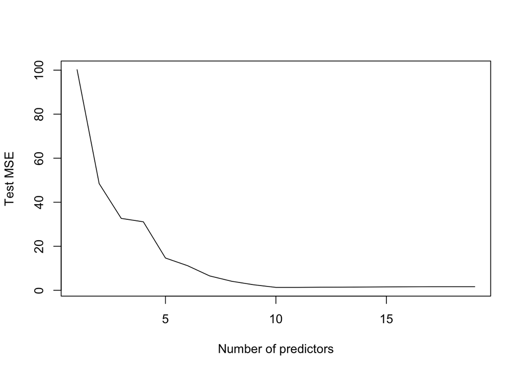

```r
#(c)
test_MSE = rep(NA,19)
for(i in 1:19){
  test.mat = model.matrix(Y~.,data=test_data)

  coef.m = coef(subset_model,id=i)
  pred = test.mat[,names(coef.m)]%*%coef.m
  test_MSE[i] = mean((test_data$Y-pred)^2)
}
plot(test_MSE, xlab = "Number of predictors", ylab = "Test MSE", type = "l")
```

```r
# (d)
min_model = which.min(test_MSE)
min_model
```

```
## [1] 10
```

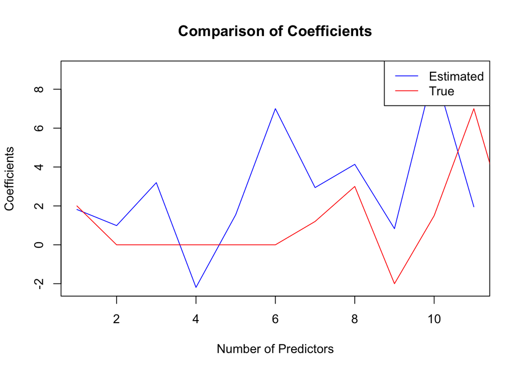

```r
#(e)
coef_subset = coef(subset_model, id = min_model)
true_coef = c(beta[1], beta[-1])

plot(coef_subset, type = "l", col = "blue", xlab = "Number of Predictors", ylab = "Coefficients", main = "Comparison of Coefficients")
lines(true_coef, col = "red")
legend("topright", legend = c("Estimated", "True"), col = c("blue", "red"), lty = 1)
```

## Problem 3

```r
library(ISLR2)

#(a)
train_index = sample(1:nrow(College), 0.9*nrow(College))
train_data = College[train_index, ]
test_data = College[-train_index, ]

regfit.fwd = regsubsets(Apps~.,data=train_data,nvmax=17, nbest = 1, method="forward")
regfit.bwd = regsubsets(Apps~.,data=train_data,nvmax=17, method="backward")

test_MSE_fwd = rep(NA, 17)
for(i in 1:17){
  test.mat = model.matrix(Apps~.,data=test_data)
  coef.m = coef(regfit.fwd,id=i)
  pred = test.mat[,names(coef.m)]%*%coef.m
  test_MSE_fwd[i] = mean((test_data$Apps-pred)^2)
}
test_MSE_fwd
```

```
##  [1] 3589452 3181322 3178466 3490075 3396032 3480350 3389341 3361720 3321574
## [10] 3705556 3418599 3443369 3477015 3451973 3451983 3446442 3446476
```

```r
cat("Model that minimizes test MSE: ", which.min(test_MSE_fwd), "\n\n")
```

```
## Model that minimizes test MSE:  3
```

```r
test_MSE_bwd = rep(NA, 17)
for(i in 1:17){
  test.mat = model.matrix(Apps~.,data=test_data)
  coef.m = coef(regfit.bwd,id=i)
  pred = test.mat[,names(coef.m)]%*%coef.m
  test_MSE_bwd[i] = mean((test_data$Apps-pred)^2)
}
test_MSE_bwd
```

```
##  [1] 3589452 3181322 3178466 3490075 3396032 3480350 3389341 3361720 3321574
## [10] 3705556 3418599 3443369 3477015 3451973 3451983 3446442 3446476
```

```r
cat("Model that minimizes test MSE: ", which.min(test_MSE_bwd), "\n")
```

```
## Model that minimizes test MSE:  3
```

1. It is not necessary that forward and backward algorithms will lead to the same model based on test MSE, but in this case they gives the same model.

```r
#(b)
full.regfit.fwd = regsubsets(Apps~.,data=College,nvmax=17, nbest = 1, method="forward")
full.regfit.bwd = regsubsets(Apps~.,data=College,nvmax=17, method="backward")

n = dim(College)[1]

full.regfit.fwd.sum = summary(full.regfit.fwd)
p.fwd = rowSums(full.regfit.fwd.sum$which)
rss.fwd = full.regfit.fwd.sum$rss
AIC.fwd = n*log(rss.fwd/n) + 2*(p.fwd)
which.min(AIC.fwd)
```

```
## 12
## 12
```

```r
full.regfit.bwd.sum = summary(full.regfit.bwd)
p.bwd = rowSums(full.regfit.bwd.sum$which)
rss.bwd = full.regfit.bwd.sum$rss
AIC.bwd = n*log(rss.bwd/n) + 2*(p.bwd)
which.min(AIC.bwd)
```

```
## 12
## 12
```

2. Both forward and backward selection gives the same model based on AIC.
3. Choosing the final model can be depended on several considerations such as the model complexity and by using some domain knowledge on the problem or dataset. Since AIC provides a more comprehensive approach to model selection that accounts for both how well the model fits the data and the model complexity by penalizing the model, choosing the best model based on AIC might be a better option.

## Problem 4

The standard error values for the coefficients of the predictors, X1 and X2, are considered large as compared to their estimates. A possible explanation for this result is multicollinearity. It happens when the predictors in the regression model are highly correlated with each other, which will leads to issues in estimating the individual effects of each predictors on the response. When multicollinearity is present, it will be challenging for the model to distinguish the unique contribution of each predictor as they are redundant in explaining the variation in the response variable. Additionally, standard errors are supposed to provide an indication of the uncertainty associated with the coefficient estimates. Hence, the coefficient estimates of the correlated variables become unstable, leading to inflated standard errors and will potentially mislead the interpretations of their effects.

## Problem 5

```r
#(a)
str(Credit)
```

```
## 'data.frame':    400 obs. of  11 variables:
##  $ Income   : num  14.9 106 104.6 148.9 55.9 ...
##  $ Limit    : num  3606 6645 7075 9504 4897 ...
##  $ Rating   : num  283 483 514 681 357 569 259 512 266 491 ...
##  $ Cards    : num  2 3 4 3 2 4 2 2 5 3 ...
##  $ Age      : num  34 82 71 36 68 77 37 87 66 41 ...
##  $ Education: num  11 15 11 11 16 10 12 9 13 19 ...
##  $ Own      : Factor w/ 2 levels "No","Yes": 1 2 1 2 1 1 2 1 2 2 ...
##  $ Student  : Factor w/ 2 levels "No","Yes": 1 2 1 1 1 1 1 1 1 2 ...
##  $ Married  : Factor w/ 2 levels "No","Yes": 2 2 1 1 2 1 1 1 1 2 ...
##  $ Region   : Factor w/ 3 levels "East","South",..: 2 3 3 3 2 2 1 3 2 1 ...
##  $ Balance  : num  333 903 580 964 331 ...
```

1. Own, Student, Married, and Region are stored as factors in R.

```r
#(b)
Credit$Student <- relevel(Credit$Student, ref = "No")

fit = lm(Balance ~ Income + Student, data = Credit)
summary(fit)
```

```
##
## Call:
## lm(formula = Balance ~ Income + Student, data = Credit)
##
## Residuals:
##     Min      1Q  Median      3Q     Max
## -762.37 -331.38  -45.04  323.60  818.28
##
## Coefficients:
##             Estimate Std. Error t value Pr(>|t|)
## (Intercept) 211.1430    32.4572   6.505 2.34e-10 ***
## Income        5.9843     0.5566  10.751  < 2e-16 ***
## StudentYes  382.6705    65.3108   5.859 9.78e-09 ***
## ---
## Signif. codes:  0 '***' 0.001 '**' 0.01 '*' 0.05 '.' 0.1 ' ' 1
##
## Residual standard error: 391.8 on 397 degrees of freedom
## Multiple R-squared:  0.2775, Adjusted R-squared:  0.2738
## F-statistic: 76.22 on 2 and 397 DF,  p-value: < 2.2e-16
```

3. Students: Balance = 211.1430 + 5.9843(Income) + 382.6705(StudentYes)  
   Non-students: Balance = 211.1430 + 5.9843(Income)
4. For both models, the coefficient of Income indicates that for each unit increase in Income, the average balance increases by approximately 5.9843, holding other predictors constant.

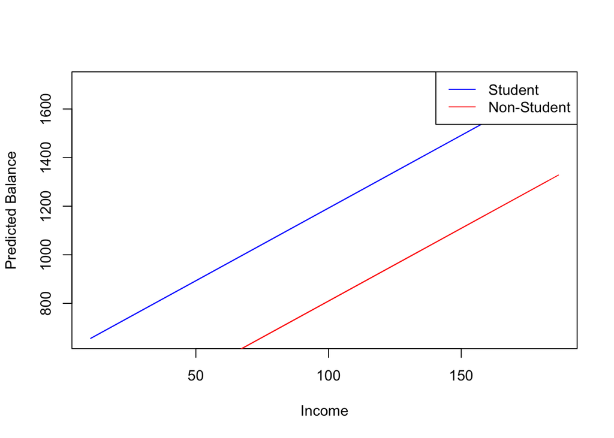

```r
#(e)
predicted_student = predict(fit, newdata = data.frame(Income = Credit$Income, Student = "Yes"))
predicted_nonstudent = predict(fit, newdata = data.frame(Income = Credit$Income, Student = "No"))

plot(Credit$Income, predicted_student, type = "l", col = "blue", xlab = "Income", ylab = "Predicted Balance")
lines(Credit$Income, predicted_nonstudent, col = "red")
legend("topright", legend = c("Student", "Non-Student"), col = c("blue", "red"), lty = 1)
```

5. The plot suggests that there is no interaction effect between Income and Student status. The effect of Income on average Balance does not differ between students and non-students.

```r
#(f)
lm(Balance ~ Income + Student + Income:Student, data=Credit)
```

```
##
## Call:
## lm(formula = Balance ~ Income + Student + Income:Student, data = Credit)
##
## Coefficients:
##       (Intercept)             Income         StudentYes  Income:StudentYes
##           200.623              6.218            476.676             -1.999
```

6. Students: Balance = 200.623 + 6.218(Income) + 476.676(StudentYes) -1.999(Income $\times$ StudentYes)  
   Non-students: Balance = 200.623 + 6.218(Income)
7. The coefficient of Income:StudentYes, -1.999, represents the additional effect of Income on Balance for students in comparison to non-students. The combined effect of Income on balance for students is 6.218 - 1.999 = 4.219. This suggests that for each unit increase in Income, the average Balance increases by 4.219 for students, holding all other predictors constant. For non-students, since there’s no interaction term for non-students, the effect of Income on Balance remains constant regardless of student status. For each unit increase in Income, the average Balance increases by 6.218, holding other predictors constant.